# Final Project - Predicting Annual Air Pollution

Xuan Jiang, Yutong Guo, Tengyue Wang

## Introduction

This project aims to harness the power of data analytics, utilizing R, to forecast annual average air pollution concentrations across the United States at the granularity of zip code regions. Air pollution remains a critical environmental challenge impacting public health, ecosystem stability, and global climate change. Its complex nature, influenced by a myriad of factors ranging from urbanization to chemical atmospheric interactions, necessitates advanced predictive models for effective management and policy planning. Air pollution, comprising various pollutants like fine particles (PM2.5), ozone (O3), nitrogen oxides (NOx), and black carbon, has been associated with a range of adverse health outcomes, including asthma, inflammation in Type 1 diabetes, lung diseases, low birth weight, and viral Infection.[1]

Traditional epidemiological approaches to assessing air pollution levels have relied on a network of stationary monitors, which are often insufficient in number and unevenly distributed, particularly in rural or underdeveloped areas. Moreover, these monitors are not strategically placed near known pollution sources, leading to potential underestimations of exposure levels, which is known as sparse monitoring. These limitations hinder the ability to accurately assess and understand the full impact of air pollution on public health.2 However, machine learning methods offer a promising solution for predicting air pollution levels. These advanced computational techniques can analyze large datasets, identifying complex patterns that are not evident through traditional analysis. By leveraging various types of data sources, such as satellite imagery, traffic patterns, industrial activity data, and meteorological information, machine learning algorithms can generate accurate predictions of air pollution levels in specific areas, even in the absence of direct monitoring data, which is particularly valuable in filling the gaps left by sparse monitoring networks.[2]

### Load packages

```r
library(tidyverse)
library(tidymodels)
library(maps)
library(lmtest)
library(randomForest)
#install.packages("maps")
#install.packages("OCSdata")
#install.packages("here")
#install.packages("skimr")
```

## Research Question

1. Can we predict US annual average air pollution concentrations at the granularity of zip code regional levels using predictors such as data about population density, urbanization, and road density, as well as, satellite pollution data and chemical modeling data?
2. How do varying levels of air pollutant concentrations across different states correlate with the mortality rates from respiratory conditions within those states？

## The Data

The dataset used in this study is an integration of data from “US Environmental Protection Agency (EPA), the National Aeronautics and Space Administration (NASA), the US Census, and the National Center for Health Statistics (NCHS),” which was initially collected by a researcher group at the Johns Hopkins School of Public Health.[3] This dataset, originating from 876 air quality monitors, provides a comprehensive view of PM2.5 (particulate matter with a diameter of less than 2.5 micrometers) concentrations across various locations. It consists of 50 columns, encompassing a wide range of environmental, geographical, and socio-demographic variables.

The dataset we used for extended data analysis is “Weekly Counts of Deaths by State and Select Causes, 2014-2019”, which was compiled by the National Center for Health Statistics (NCHS) and published on April 1st, 2022. It records the number of deaths, categorized by specific causes, on a weekly basis. We focus on the column that contains the death counts of respiratory diseases in this study.[4]

### Data Import

```r
# Load the dataset
# OCSdata::raw_data("ocs-bp-air-pollution", outpath = getwd())
df <- readr::read_csv(here::here("OCS_data", "data","raw", "pm25_data.csv"))
# View the dataset
df
```

```
## # A tibble: 876 × 50
##       id value  fips   lat   lon state   county    city     CMAQ  zcta zcta_area
##    <dbl> <dbl> <dbl> <dbl> <dbl> <chr>   <chr>     <chr>   <dbl> <dbl>     <dbl>
##  1 1003.  9.60  1003  30.5 -87.9 Alabama Baldwin   Fairho…  8.10 36532 190980522
##  2 1027. 10.8   1027  33.3 -85.8 Alabama Clay      Ashland  9.77 36251 374132430
##  3 1033. 11.2   1033  34.8 -87.7 Alabama Colbert   Muscle…  9.40 35660  16716984
##  4 1049. 11.7   1049  34.3 -86.0 Alabama DeKalb    Crossv…  8.53 35962 203836235
##  5 1055. 12.4   1055  34.0 -86.0 Alabama Etowah    Gadsden  9.24 35901 154069359
##  6 1069. 10.5   1069  31.2 -85.4 Alabama Houston   Dothan   9.12 36303 162685124
##  7 1073. 15.6   1073  33.6 -86.8 Alabama Jefferson Birmin… 10.2  35207  26929603
##  8 1073. 12.4   1073  33.3 -87.0 Alabama Jefferson Not in… 10.2  35111 166239542
##  9 1073. 11.1   1073  33.5 -87.3 Alabama Jefferson Not in…  8.16 35444 385566685
## 10 1073. 13.1   1073  33.5 -86.5 Alabama Jefferson Leeds    9.30 35094 148994881
## # ℹ 866 more rows
## # ℹ 39 more variables: zcta_pop <dbl>, imp_a500 <dbl>, imp_a1000 <dbl>,
## #   imp_a5000 <dbl>, imp_a10000 <dbl>, imp_a15000 <dbl>, county_area <dbl>,
## #   county_pop <dbl>, log_dist_to_prisec <dbl>, log_pri_length_5000 <dbl>,
## #   log_pri_length_10000 <dbl>, log_pri_length_15000 <dbl>,
## #   log_pri_length_25000 <dbl>, log_prisec_length_500 <dbl>,
## #   log_prisec_length_1000 <dbl>, log_prisec_length_5000 <dbl>, …
```

### Data Wrangling

```r
# Get an overall sense of the dataset
skimr::skim(df)
```

Data summary

| Name | df |
| --- | --- |
| Number of rows | 876 |
| Number of columns | 50 |
| _______________________ |  |
| Column type frequency: |  |
| character | 3 |
| numeric | 47 |
| ________________________ |  |
| Group variables | None |

**Variable type: character**

| skim_variable | n_missing | complete_rate | min | max | empty | n_unique | whitespace |
| --- | --- | --- | --- | --- | --- | --- | --- |
| state | 0 | 1 | 4 | 20 | 0 | 49 | 0 |
| county | 0 | 1 | 3 | 20 | 0 | 471 | 0 |
| city | 0 | 1 | 4 | 48 | 0 | 607 | 0 |

**Variable type: numeric**

| skim_variable | n_missing | complete_rate | mean | sd | p0 | p25 | p50 | p75 | p100 | hist |
| --- | --- | --- | --- | --- | --- | --- | --- | --- | --- | --- |
| id | 0 | 1 | 26987.96 | 1.578761e+04 | 1003.00 | 13089.15 | 26132.00 | 39118.00 | 5.603910e+04 | ▇▇▆▇▆ |
| value | 0 | 1 | 10.81 | 2.580000e+00 | 3.02 | 9.27 | 11.15 | 12.37 | 2.316000e+01 | ▂▆▇▁▁ |
| fips | 0 | 1 | 26987.89 | 1.578763e+04 | 1003.00 | 13089.00 | 26132.00 | 39118.00 | 5.603900e+04 | ▇▇▆▇▆ |
| lat | 0 | 1 | 38.48 | 4.620000e+00 | 25.47 | 35.03 | 39.30 | 41.66 | 4.840000e+01 | ▁▃▅▇▂ |
| lon | 0 | 1 | -91.74 | 1.496000e+01 | -124.18 | -99.16 | -87.47 | -80.69 | -6.804000e+01 | ▃▂▃▇▃ |
| CMAQ | 0 | 1 | 8.41 | 2.970000e+00 | 1.63 | 6.53 | 8.62 | 10.24 | 2.313000e+01 | ▃▇▃▁▁ |
| zcta | 0 | 1 | 50890.29 | 2.778447e+04 | 1022.00 | 28788.25 | 48172.00 | 74371.00 | 9.920200e+04 | ▅▇▇▅▇ |
| zcta_area | 0 | 1 | 183173481.91 | 5.425989e+08 | 15459.00 | 14204601.75 | 37653560.50 | 160041508.25 | 8.164821e+09 | ▇▁▁▁▁ |
| zcta_pop | 0 | 1 | 24227.58 | 1.777216e+04 | 0.00 | 9797.00 | 22014.00 | 35004.75 | 9.539700e+04 | ▇▇▃▁▁ |
| imp_a500 | 0 | 1 | 24.72 | 1.934000e+01 | 0.00 | 3.70 | 25.12 | 40.22 | 6.961000e+01 | ▇▅▆▃▂ |
| imp_a1000 | 0 | 1 | 24.26 | 1.802000e+01 | 0.00 | 5.32 | 24.53 | 38.59 | 6.750000e+01 | ▇▅▆▃▁ |
| imp_a5000 | 0 | 1 | 19.93 | 1.472000e+01 | 0.05 | 6.79 | 19.07 | 30.11 | 7.460000e+01 | ▇▆▃▁▁ |
| imp_a10000 | 0 | 1 | 15.82 | 1.381000e+01 | 0.09 | 4.54 | 12.36 | 24.17 | 7.209000e+01 | ▇▃▂▁▁ |
| imp_a15000 | 0 | 1 | 13.43 | 1.312000e+01 | 0.11 | 3.24 | 9.67 | 20.55 | 7.110000e+01 | ▇▃▁▁▁ |
| county_area | 0 | 1 | 3768701992.12 | 6.212830e+09 | 33703512.00 | 1116536297.50 | 1690826566.50 | 2878192209.00 | 5.194723e+10 | ▇▁▁▁▁ |
| county_pop | 0 | 1 | 687298.44 | 1.293489e+06 | 783.00 | 100948.00 | 280730.50 | 743159.00 | 9.818605e+06 | ▇▁▁▁▁ |
| log_dist_to_prisec | 0 | 1 | 6.19 | 1.410000e+00 | -1.46 | 5.43 | 6.36 | 7.15 | 1.045000e+01 | ▁▁▃▇▁ |
| log_pri_length_5000 | 0 | 1 | 9.82 | 1.080000e+00 | 8.52 | 8.52 | 10.05 | 10.73 | 1.205000e+01 | ▇▂▆▅▂ |
| log_pri_length_10000 | 0 | 1 | 10.92 | 1.130000e+00 | 9.21 | 9.80 | 11.17 | 11.83 | 1.302000e+01 | ▇▂▇▇▃ |
| log_pri_length_15000 | 0 | 1 | 11.50 | 1.150000e+00 | 9.62 | 10.87 | 11.72 | 12.40 | 1.359000e+01 | ▆▂▇▇▃ |
| log_pri_length_25000 | 0 | 1 | 12.24 | 1.100000e+00 | 10.13 | 11.69 | 12.46 | 13.05 | 1.436000e+01 | ▅▃▇▇▃ |
| log_prisec_length_500 | 0 | 1 | 6.99 | 9.500000e-01 | 6.21 | 6.21 | 6.21 | 7.82 | 9.400000e+00 | ▇▁▂▂▁ |
| log_prisec_length_1000 | 0 | 1 | 8.56 | 7.900000e-01 | 7.60 | 7.60 | 8.66 | 9.20 | 1.047000e+01 | ▇▅▆▃▁ |
| log_prisec_length_5000 | 0 | 1 | 11.28 | 7.800000e-01 | 8.52 | 10.91 | 11.42 | 11.83 | 1.278000e+01 | ▁▁▃▇▃ |
| log_prisec_length_10000 | 0 | 1 | 12.41 | 7.300000e-01 | 9.21 | 11.99 | 12.53 | 12.94 | 1.385000e+01 | ▁▁▃▇▅ |
| log_prisec_length_15000 | 0 | 1 | 13.03 | 7.200000e-01 | 9.62 | 12.59 | 13.13 | 13.57 | 1.441000e+01 | ▁▁▃▇▅ |
| log_prisec_length_25000 | 0 | 1 | 13.82 | 7.000000e-01 | 10.13 | 13.38 | 13.92 | 14.35 | 1.523000e+01 | ▁▁▃▇▆ |
| log_nei_2008_pm25_sum_10000 | 0 | 1 | 3.97 | 2.350000e+00 | 0.00 | 2.15 | 4.29 | 5.69 | 9.120000e+00 | ▆▅▇▆▂ |
| log_nei_2008_pm25_sum_15000 | 0 | 1 | 4.72 | 2.250000e+00 | 0.00 | 3.47 | 5.00 | 6.35 | 9.420000e+00 | ▃▃▇▇▂ |
| log_nei_2008_pm25_sum_25000 | 0 | 1 | 5.67 | 2.110000e+00 | 0.00 | 4.66 | 5.91 | 7.28 | 9.650000e+00 | ▂▂▇▇▃ |
| log_nei_2008_pm10_sum_10000 | 0 | 1 | 4.35 | 2.320000e+00 | 0.00 | 2.69 | 4.62 | 6.07 | 9.340000e+00 | ▅▅▇▇▂ |
| log_nei_2008_pm10_sum_15000 | 0 | 1 | 5.10 | 2.180000e+00 | 0.00 | 3.87 | 5.39 | 6.72 | 9.710000e+00 | ▂▃▇▇▂ |
| log_nei_2008_pm10_sum_25000 | 0 | 1 | 6.07 | 2.010000e+00 | 0.00 | 5.10 | 6.37 | 7.52 | 9.880000e+00 | ▁▂▆▇▃ |
| popdens_county | 0 | 1 | 551.76 | 1.711510e+03 | 0.26 | 40.77 | 156.67 | 510.81 | 2.682191e+04 | ▇▁▁▁▁ |
| popdens_zcta | 0 | 1 | 1279.66 | 2.757490e+03 | 0.00 | 101.15 | 610.35 | 1382.52 | 3.041884e+04 | ▇▁▁▁▁ |
| nohs | 0 | 1 | 6.99 | 7.210000e+00 | 0.00 | 2.70 | 5.10 | 8.80 | 1.000000e+02 | ▇▁▁▁▁ |
| somehs | 0 | 1 | 10.17 | 6.200000e+00 | 0.00 | 5.90 | 9.40 | 13.90 | 7.220000e+01 | ▇▂▁▁▁ |
| hs | 0 | 1 | 30.32 | 1.140000e+01 | 0.00 | 23.80 | 30.75 | 36.10 | 1.000000e+02 | ▂▇▂▁▁ |
| somecollege | 0 | 1 | 21.58 | 8.600000e+00 | 0.00 | 17.50 | 21.30 | 24.70 | 1.000000e+02 | ▆▇▁▁▁ |
| associate | 0 | 1 | 7.13 | 4.010000e+00 | 0.00 | 4.90 | 7.10 | 8.80 | 7.140000e+01 | ▇▁▁▁▁ |
| bachelor | 0 | 1 | 14.90 | 9.710000e+00 | 0.00 | 8.80 | 12.95 | 19.22 | 1.000000e+02 | ▇▂▁▁▁ |
| grad | 0 | 1 | 8.91 | 8.650000e+00 | 0.00 | 3.90 | 6.70 | 11.00 | 1.000000e+02 | ▇▁▁▁▁ |
| pov | 0 | 1 | 14.95 | 1.133000e+01 | 0.00 | 6.50 | 12.10 | 21.22 | 6.590000e+01 | ▇▅▂▁▁ |
| hs_orless | 0 | 1 | 47.48 | 1.675000e+01 | 0.00 | 37.92 | 48.65 | 59.10 | 1.000000e+02 | ▁▃▇▃▁ |
| urc2013 | 0 | 1 | 2.92 | 1.520000e+00 | 1.00 | 2.00 | 3.00 | 4.00 | 6.000000e+00 | ▇▅▃▂▁ |
| urc2006 | 0 | 1 | 2.97 | 1.520000e+00 | 1.00 | 2.00 | 3.00 | 4.00 | 6.000000e+00 | ▇▅▃▂▁ |
| aod | 0 | 1 | 43.70 | 1.956000e+01 | 5.00 | 31.66 | 40.17 | 49.67 | 1.430000e+02 | ▃▇▁▁▁ |

```r
# Select the columns that we needed and rename the dataset to "pm"
pm <- subset(df, select = c(value, state, county, lat, lon, county_pop, log_prisec_length_1000, popdens_county, popdens_zcta, pov, urc2013, aod, CMAQ ))
# Rename the column name to aid understanding
pm <- pm |> rename("log_RoadLength_1kmRadius" = "log_prisec_length_1000",
                   "optical_depth" = "aod")
# View the wrangled dataset "pm"
view(pm)
```

### Exploratory Data Analysis

In approaching this question, we first visualize the distribution of PM2.5 values across states to gain a broad overview of air quality throughout the United States. This approach can highlight regional variations and potential hotspots of pollution. By mapping PM2.5 levels on a state-by-state basis, we can swiftly identify areas with higher pollution levels. This provides valuable context before we delve into a more granular analysis at the zip code level.

**Figure1:** Spatial Distribution of PM 2.5 Values

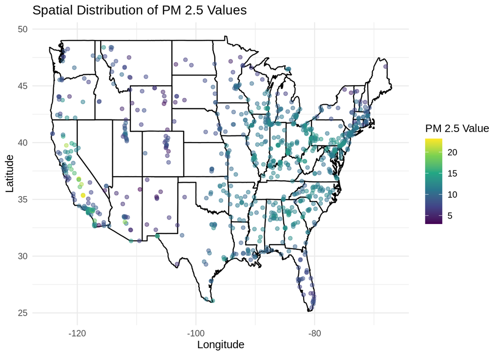

```r
ggplot(pm, aes(x = lon, y = lat, color = value)) +
  borders("state", colour = "black", fill = "white") +
  geom_point(alpha = 0.5) +
  scale_color_viridis_c() +
  labs(title = "Spatial Distribution of PM 2.5 Values",
       x = "Longitude", y = "Latitude", color = "PM 2.5 Value") +
  theme_minimal()
```

**Figure2:** Spatial Distribution of CMAQ Values

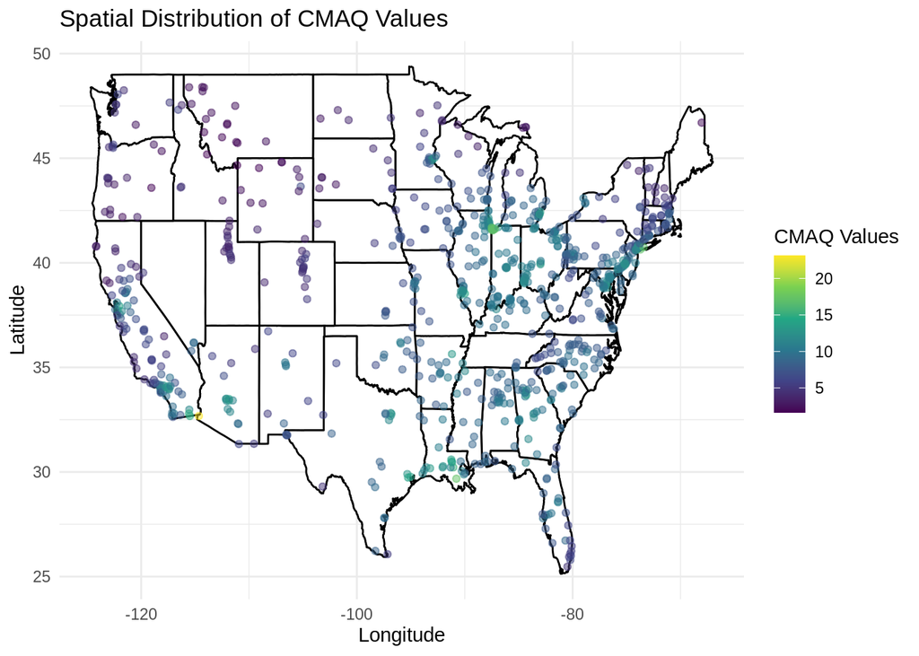

```r
ggplot(pm, aes(x = lon, y = lat, color = CMAQ)) +
  borders("state", colour = "black", fill = "white") +
  geom_point(alpha = 0.5) +
  scale_color_viridis_c() +
  labs(title = "Spatial Distribution of CMAQ Values",
       x = "Longitude", y = "Latitude", color = "CMAQ Values") +
  theme_minimal()
```

**Figure3:** The box-plot of PM 2.5 Values of the state

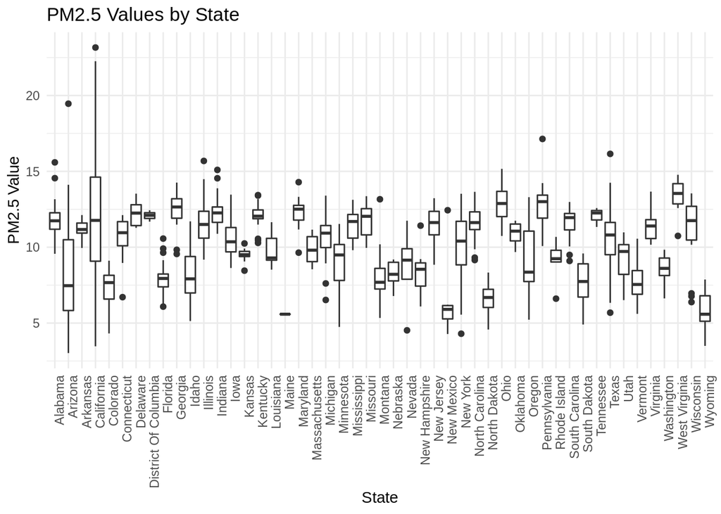

```r
ggplot(pm, aes(x = state, y = value)) +
  geom_boxplot() +
  labs(title = "PM2.5 Values by State",
       x = "State",
       y = "PM2.5 Value") +
  theme_minimal() +
  theme(axis.text.x = element_text(angle = 90, hjust = 1))
```

Then we created a boxplot to compare the pm 2.5 value of each state. This way we have a better idea of the distribution of the data, which would serve well in the later extended analysis while comparing state air pollution level by death.

**Figure4:** Relationship between PM 2.5 values and poverty

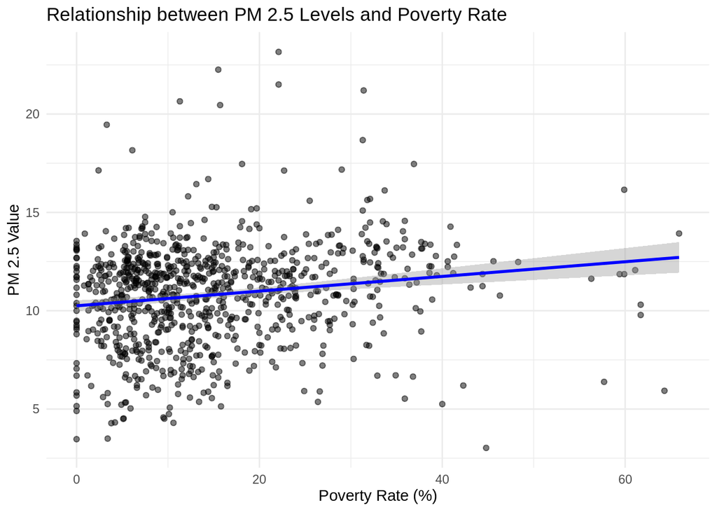

```r
#PM 2. 5 levels versus poverty
ggplot(df, aes(x = pov, y = value)) +
  geom_point(alpha = 0.5) +
  geom_smooth(method = "lm", color = "blue") +
  labs(title = "Relationship between PM 2.5 Levels and Poverty Rate",
       x = "Poverty Rate (%)", y = "PM 2.5 Value") +
  theme_minimal()
```

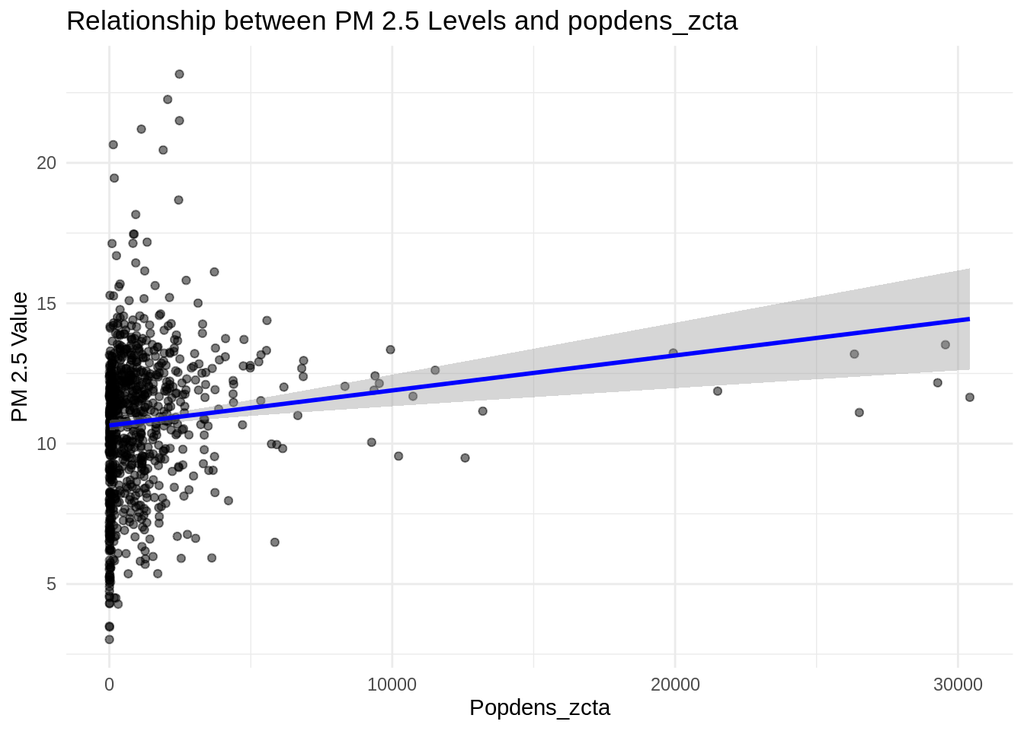

```r
#PM 2.5 levels versus popdens_zcta
ggplot(df, aes(x = popdens_zcta, y = value)) +
  geom_point(alpha = 0.5) +
  geom_smooth(method = "lm", color = "blue") +
  labs(title = "Relationship between PM 2.5 Levels and popdens_zcta",
       x = "Popdens_zcta", y = "PM 2.5 Value") +
  theme_minimal()
```

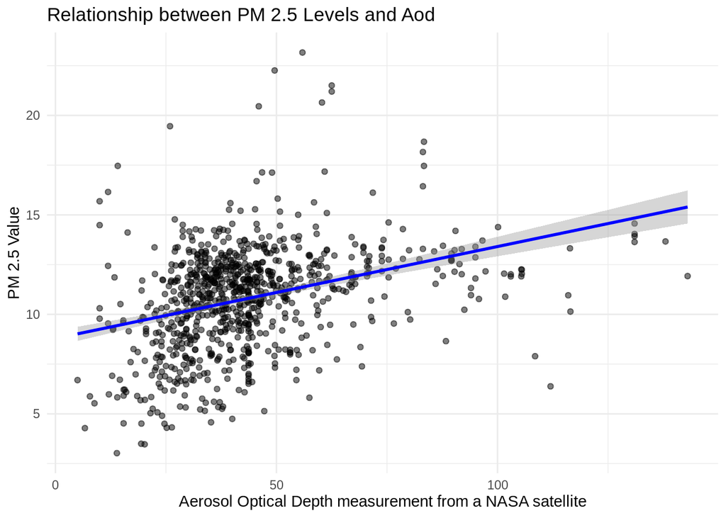

```r
#PM 2.5 levels versus Aerosol Optical Depth measurement from a NASA satellite
ggplot(df, aes(x = aod, y = value)) +
  geom_point(alpha = 0.5) +
  geom_smooth(method = "lm", color = "blue") +
  labs(title = "Relationship between PM 2.5 Levels and Aod",
       x = "Aerosol Optical Depth measurement from a NASA satellite", y = "PM 2.5 Value") +
  theme_minimal()
```

## Data Analysis

```r
#correlation matrix
cor_matrix <- cor(pm |>
                    select(popdens_zcta, urc2013, log_RoadLength_1kmRadius, optical_depth, CMAQ, value))
cor_matrix
```

```
##                          popdens_zcta    urc2013 log_RoadLength_1kmRadius
## popdens_zcta                1.0000000 -0.3244017                0.1432321
## urc2013                    -0.3244017  1.0000000               -0.2424497
## log_RoadLength_1kmRadius    0.1432321 -0.2424497                1.0000000
## optical_depth               0.2214174 -0.4370799                0.1464872
## CMAQ                        0.1634752 -0.4491541                0.1225833
## value                       0.1330540 -0.2508474                0.2053322
##                          optical_depth       CMAQ      value
## popdens_zcta                 0.2214174  0.1634752  0.1330540
## urc2013                     -0.4370799 -0.4491541 -0.2508474
## log_RoadLength_1kmRadius     0.1464872  0.1225833  0.2053322
## optical_depth                1.0000000  0.3477286  0.3498192
## CMAQ                         0.3477286  1.0000000  0.4661511
## value                        0.3498192  0.4661511  1.0000000
```

We can first run a correlation matrix between the 5 main factors and the pm 2.5 value to see wheather there is a significant correlation between each factor and the pm 2.5 value.

**Result**: Looking at the last column of this table: The slight positive correlation between population density and PM2.5 values (0.1330540) suggests that areas with higher numbers of people could have increased emissions from sources like vehicles and industrial activities, contributing to higher PM2.5 levels. Despite being a weak correlation, population density still carries potential predictive value as a proxy for human-related pollution sources.The modest negative correlation between urbanization level and PM2.5 values (-0.2508474) indicates an inverse relationship where more urbanized areas could exhibit lower PM2.5 levels. This could be attributed to better infrastructure for pollution control and regulation enforcement in highly urbanized areas. Although the result is counter-intuitive, the variable urbanization level could still serve as a valuable predictor in the model. The moderate positive correlation between log-transformed road length within a 1 km radius and PM2.5 values (0.2053322) points towards road length being a good indicator of vehicular emissions, which are a major source of air pollution. The correlation between the Satellite Data (optical_depth) and the PM2.5 values is 0.3498.This represents a moderate positive correlation, suggesting a more substantial relationship where higher optical depth readings are associated with higher PM2.5 values.The correlation betwee the Chemical Modeling Data (CMAQ) and the PM2.5 values is 0.4662. This is the strongest correlation observed among the predictors. It indicates a moderate to strong positive correlation, suggesting that higher CMAQ values are significantly associated with higher PM2.5 values.

```r
#linear regression
model_popdens <- lm(value ~ popdens_zcta, data = pm)
model_urbanization <- lm(value ~urc2013, data = pm)
model_roaddens <- lm(value ~ log_RoadLength_1kmRadius, data = pm)
model_optdep <- lm(value ~ optical_depth, data = pm)
model_CMAQ <- lm(value ~ CMAQ, data = pm)

summary(model_CMAQ)
```

```
##
## Call:
## lm(formula = value ~ CMAQ, data = pm)
##
## Residuals:
##     Min      1Q  Median      3Q     Max
## -7.2111 -1.1867  0.0453  1.1415 13.4337
##
## Coefficients:
##             Estimate Std. Error t value Pr(>|t|)
## (Intercept)  7.39757    0.23216   31.86   <2e-16 ***
## CMAQ         0.40530    0.02602   15.58   <2e-16 ***
## ---
## Signif. codes:  0 '***' 0.001 '**' 0.01 '*' 0.05 '.' 0.1 ' ' 1
##
## Residual standard error: 2.286 on 874 degrees of freedom
## Multiple R-squared:  0.2173, Adjusted R-squared:  0.2164
## F-statistic: 242.6 on 1 and 874 DF,  p-value: < 2.2e-16
```

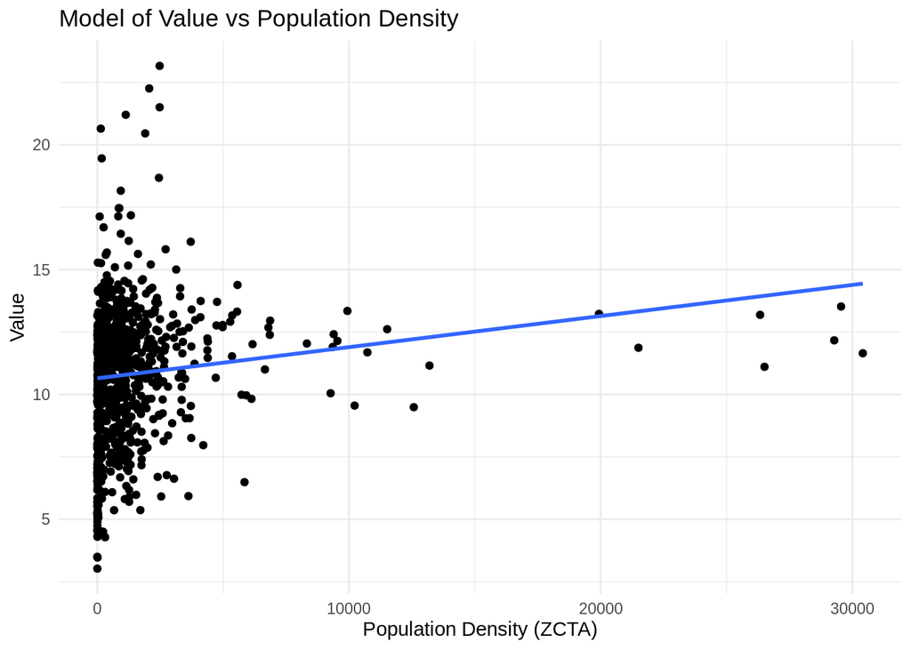

```r
#Visualizations
# Model with population density
ggplot(pm, aes(x = popdens_zcta, y = value)) +
  geom_point() +
  geom_smooth(method = "lm", se = FALSE) +
  labs(title = "Model of Value vs Population Density",
       x = "Population Density (ZCTA)",
       y = "Value") +
  theme_minimal()
```

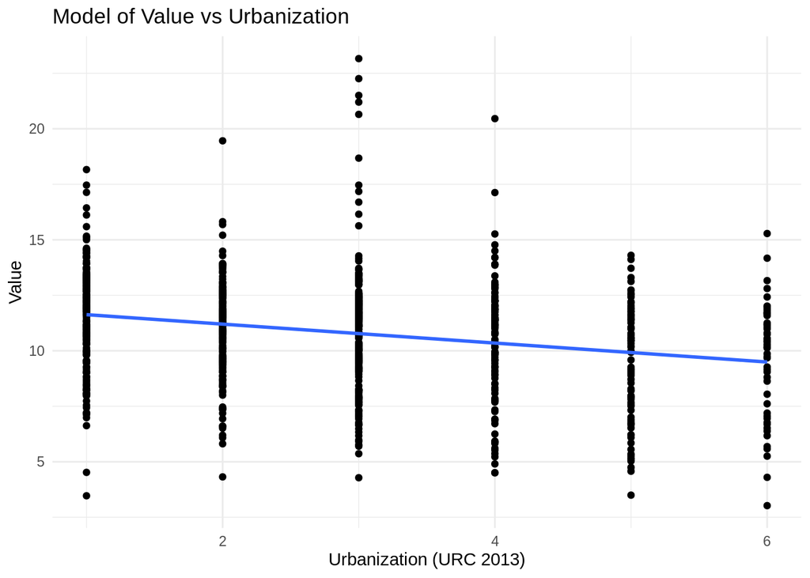

```r
# Model with urbanization
ggplot(pm, aes(x = urc2013, y = value)) +
  geom_point() +
  geom_smooth(method = "lm", se = FALSE) +
  labs(title = "Model of Value vs Urbanization",
       x = "Urbanization (URC 2013)",
       y = "Value") +
  theme_minimal()
```

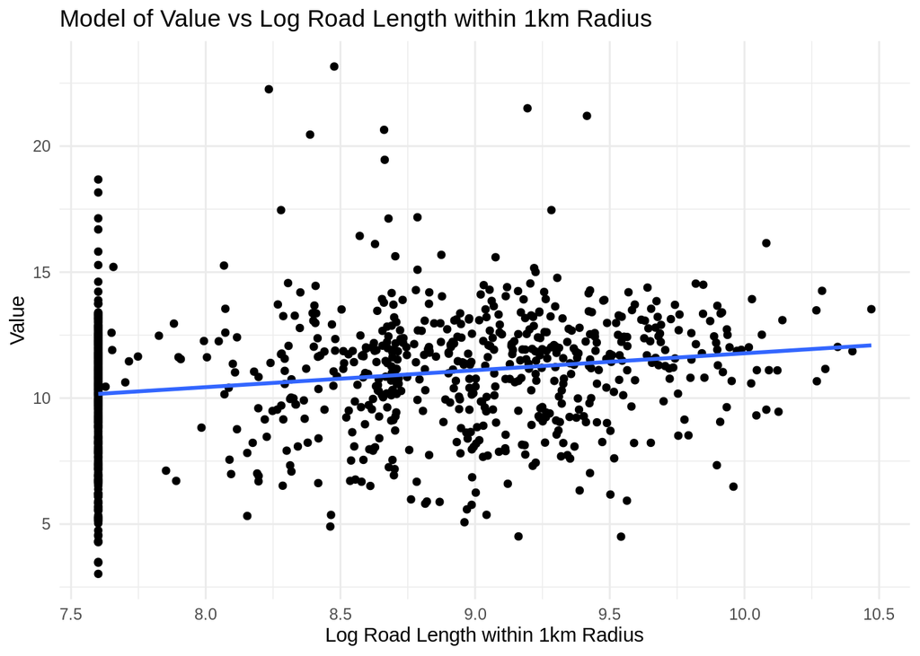

```r
# Model with road density
ggplot(pm, aes(x = log_RoadLength_1kmRadius, y = value)) +
  geom_point() +
  geom_smooth(method = "lm", se = FALSE) +
  labs(title = "Model of Value vs Log Road Length within 1km Radius",
       x = "Log Road Length within 1km Radius",
       y = "Value") +
  theme_minimal()
```

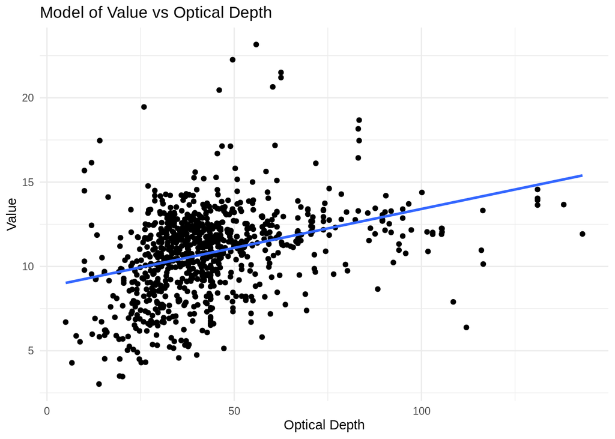

```r
# Model with optical depth
ggplot(pm, aes(x = optical_depth, y = value)) +
  geom_point() +
  geom_smooth(method = "lm", se = FALSE) +
  labs(title = "Model of Value vs Optical Depth",
       x = "Optical Depth",
       y = "Value") +
  theme_minimal()
```

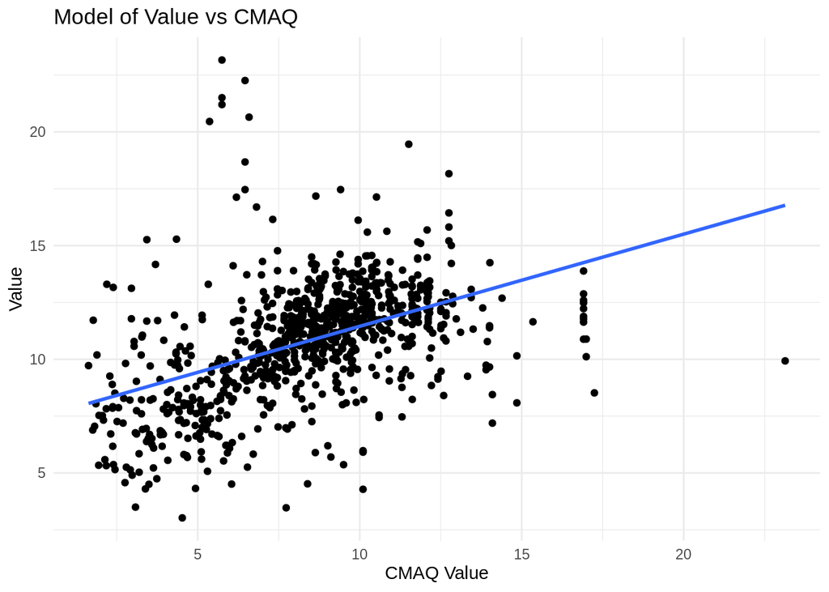

```r
# Model with CMAQ
ggplot(pm, aes(x = CMAQ, y = value)) +
  geom_point() +
  geom_smooth(method = "lm", se = FALSE) +
  labs(title = "Model of Value vs CMAQ",
       x = "CMAQ Value",
       y = "Value") +
  theme_minimal()
```

Here we plotted the linear regression graph of each of the 5 factors against pm 2.5 value.

**Result**: We can see that there is a slight positive relationship between pm 2.5 value and population density, road density (represented by log raod lenth within 1 km radius), and optic depth. There is a pretty significant positive relationship between pm 2.5 value and CMAQ value, and a slight negative realtionship between pm 2.5 value and urbanization, which is a suprising result.

```r
# Model Evaluation
summary(model_popdens)$coefficients
```

```
##                  Estimate   Std. Error   t value     Pr(>|t|)
## (Intercept)  1.064832e+01 9.541516e-02 111.59991 0.000000e+00
## popdens_zcta 1.246286e-04 3.140184e-05   3.96883 7.815391e-05
```

```r
summary(model_urbanization)$coefficients
```

```
##               Estimate Std. Error   t value     Pr(>|t|)
## (Intercept) 12.0534937 0.18326112 65.772238 0.000000e+00
## urc2013     -0.4265924 0.05568459 -7.660869 4.898523e-14
```

```r
summary(model_roaddens)$coefficients
```

```
##                           Estimate Std. Error  t value     Pr(>|t|)
## (Intercept)              5.0616001  0.9303673 5.440432 6.903711e-08
## log_RoadLength_1kmRadius 0.6716009  0.1082791 6.202496 8.565639e-10
```

```r
summary(model_optdep)$coefficients
```

```
##                 Estimate  Std. Error  t value      Pr(>|t|)
## (Intercept)   8.78938162 0.200302818 43.88047 3.790832e-223
## optical_depth 0.04619311 0.004184395 11.03938  1.288492e-26
```

```r
summary(model_CMAQ)$coefficients
```

```
##              Estimate Std. Error  t value      Pr(>|t|)
## (Intercept) 7.3975717 0.23215680 31.86455 1.809259e-148
## CMAQ        0.4052962 0.02601888 15.57700  1.830965e-48
```

```r
# Extract model summaries using glance
summary_popdens <- glance(model_popdens)
summary_urbanization <- glance(model_urbanization)
summary_roaddens <- glance(model_roaddens)
summary_optdep<- glance(model_optdep)
summary_CMAQ <- glance(model_CMAQ)

# Add a column to each summary to indicate the model
summary_popdens$model <- "Population Density"
summary_urbanization$model <- "Urbanization Level"
summary_roaddens$model <- "Road Density"
summary_optdep$model <- "Satellite Data"
summary_CMAQ$model <- "Chemical Modeling Data"

factors <- c("PopDens", "Urbanization", "RoadDens", "OptDep", "CMAQ")

# Bind the rows and add the 'factor' column
combined_summary <- bind_rows(
  summary_popdens %>% mutate(factor = factors[1]),
  summary_urbanization %>% mutate(factor = factors[2]),
  summary_roaddens %>% mutate(factor = factors[3]),
  summary_optdep %>% mutate(factor = factors[4]),
  summary_CMAQ %>% mutate(factor = factors[5])
)

combined_summary <- combined_summary %>%
  select(factor, everything())

combined_summary
```

```
## # A tibble: 5 × 14
##   factor     r.squared adj.r.squared sigma statistic  p.value    df logLik   AIC
##   <chr>          <dbl>         <dbl> <dbl>     <dbl>    <dbl> <dbl>  <dbl> <dbl>
## 1 PopDens       0.0177        0.0166  2.56      15.8 7.82e- 5     1 -2066. 4138.
## 2 Urbanizat…    0.0629        0.0619  2.50      58.7 4.90e-14     1 -2045. 4097.
## 3 RoadDens      0.0422        0.0411  2.53      38.5 8.57e-10     1 -2055. 4116.
## 4 OptDep        0.122         0.121   2.42     122.  1.29e-26     1 -2017. 4039.
## 5 CMAQ          0.217         0.216   2.29     243.  1.83e-48     1 -1966. 3939.
## # ℹ 5 more variables: BIC <dbl>, deviance <dbl>, df.residual <int>, nobs <int>,
## #   model <chr>
```

To better interpret the result from our linear regression model above, we printed the result table of our linear regression models. The Pr(>|t|) column here can tell us the probability that the result is significant.

**Result:**

Coefficient for Population Density: 1.246e-04 This model suggests a slight positive relationship between population density and the response variable. However, the relatively small coefficient indicates that population density is not a strong predictor for estimating the air pollution. The R-squared value of 0.0177 reflects this, showing that only a small percentage of the variability in the response variable is explained by population density alone.

Coefficient for Urbanization Level: -0.4266 The negative coefficient here implies that as the urbanization level increases, the value decreases. This could suggest that more urbanized areas are associated with lower values of the response variable. The R-squared value of 0.0629, though higher than that for population density, still accounts for only a modest amount of the variance, which indicates that urbanization, while a significant factor, is not the sole determinant of air pollution levels.

Coefficient for Road Density: 0.6716 This positive coefficient indicates that an increase in road density is associated with an increase in the response variable. The magnitude of the coefficient suggests a moderate relationship, indicating that road density is a good predictor for building the air pollution forecasting model. The model’s R-squared value of 0.0422 supports this, showing that road density explains a larger proportion of the variance than population density but is still a relatively modest predictor.

Coefficient for Optical Depth: 0.0462 A positive coefficient here suggests that higher optical depth readings correlate with higher values of the response variable. This relationship is more pronounced compared to the previous models, as indicated by the coefficient’s magnitude. An R-squared value of 0.1224 indicates that optical depth is a significant predictor, explaining a more considerable portion of the variance in the response variable.

Coefficient for CMAQ: 0.4053 This model shows a significant positive relationship between CMAQ values and the response variable, implying that higher CMAQ values are associated with higher values of the response variable. The R-squared value of 0.2173 is quite significant, indicating that this model has a strong predictive power and that CMAQ is a robust predictor of air pollution levels.

```r
# Split the dataset into training data and testing data
set.seed(1234) #ensures we all get the exact same random split
pm_split <- rsample::initial_split(data = pm, prop = 2/3)
pm_split
```

```
## <Analysis/Assess/Total>
## <584/292/876>
```

```r
train_pm <- rsample::training(pm_split)
test_pm <- rsample::testing(pm_split)

count(train_pm, state)
```

```
## # A tibble: 49 × 2
##    state                    n
##    <chr>                <int>
##  1 Alabama                 13
##  2 Arizona                 12
##  3 Arkansas                 8
##  4 California              55
##  5 Colorado                10
##  6 Connecticut             12
##  7 Delaware                 3
##  8 District Of Columbia     2
##  9 Florida                 22
## 10 Georgia                 20
## # ℹ 39 more rows
```

```r
# Training the random forest model
model_rf <- randomForest(value ~ popdens_zcta +
                        urc2013 +
                        log_RoadLength_1kmRadius +
                        optical_depth +
                        CMAQ,
                      data = train_pm)

# Evaluating the model
predictions_rf <- predict(model_rf, test_pm)
mae_rf <- mean(abs(predictions_rf - test_pm$value))
rmse_rf <- sqrt(mean((predictions_rf - test_pm$value)^2))

print(paste("MAE_RF:", mae_rf))
```

```
## [1] "MAE_RF: 1.4696003202423"
```

```r
print(paste("RMSE_RF:", rmse_rf))
```

```
## [1] "RMSE_RF: 1.99923067088386"
```

```r
# Training the Linear Regression Model
model_lm <- lm(value ~ popdens_zcta +
                 urc2013 +
                 log_RoadLength_1kmRadius +
                 optical_depth +
                 CMAQ,
               data = train_pm)

# Evaluating the model
predictions_lm <- predict(model_lm, test_pm)
mae_lm <- mean(abs(predictions_lm - test_pm$value))
rmse_lm <- sqrt(mean((predictions_lm - test_pm$value)^2))

print(paste("MAE_LM:", mae_lm))
```

```
## [1] "MAE_LM: 1.55485393592348"
```

```r
print(paste("RMSE_LM:", rmse_lm))
```

```
## [1] "RMSE_LM: 2.17974945121081"
```

In order to find a model that can have better accuracy. We used a classic ranfom forest model, trained and testes its performance on this dataset. Here we splited the Train dataset to be 2/3 of the dataset (584 observations), and Test dataset is 1/3 of the dataset (292 observations) Total (pm): 584+292 = 876 observations.

### Extended Data Analysis

Refining our principal analytical question, we now concentrate on the relationship between air quality and mortality due to respiratory diseases at the state level. This pivot is necessitated by the granularity of our newly sourced dataset from the Centers for Disease Control and Prevention (CDC), which provides insights into weekly counts of deaths by state for select causes, including respiratory diseases.

Our revised hypothesis suggests that states burdened with higher air pollutant concentrations will report higher mortality rates from respiratory conditions. To test this hypothesis, we will implement statistical tests such as t-tests or z-tests. These will compare the mean mortality rates across states categorized by varying levels of pollution. This statistical approach will elucidate the significance of the differences in mortality rates and allow us to assess the public health implications of air pollution across the United States.

The CDC dataset is accessible here: [Weekly Counts of Deaths by State and Select Causes](https://data.cdc.gov/NCHS/Weekly-Counts-of-Deaths-by-State-and-Select-Causes/3yf8-kanr/about_data).

```r
# Data Cleaning for health dataset
health <- readr::read_csv(here::here("OCS_data", "data","raw", "health_data.csv"))
health <- health %>%
  select(`Chronic lower respiratory diseases (J40-J47)`,
         `Other diseases of respiratory system (J00-J06,J30-J39,J67,J70-J98)`,
         `Jurisdiction of Occurrence`) |>
  rename(
    CLow = `Chronic lower respiratory diseases (J40-J47)`,
    Other = `Other diseases of respiratory system (J00-J06,J30-J39,J67,J70-J98)`,
    State = `Jurisdiction of Occurrence`
  )|>
  filter(State != "United States")|>
  mutate(across(everything(), ~replace_na(., 0)))|>
  group_by(State) |>
  summarise(Other = sum(Other),CLow = sum(CLow))

pm <- readr::read_csv(here::here("OCS_data", "data","raw", "pm25_data.csv"))
pm_ext <- pm %>%
  select(state, value) |>
  rename(State = `state`)|>
  group_by(State) |>
  summarise(mean_value = mean(value, na.rm = TRUE))

ext <- left_join(pm_ext, health, by = "State")
ext <- drop_na(ext)
ext
```

```
## # A tibble: 48 × 4
##    State       mean_value Other  CLow
##    <chr>            <dbl> <dbl> <dbl>
##  1 Alabama          11.8   5269 19922
##  2 Arizona           8.57  3858 22340
##  3 Arkansas         11.2    881 13754
##  4 California       12.2  16805 80730
##  5 Colorado          7.34  2448 15419
##  6 Connecticut      10.6   2342  8493
##  7 Delaware         12.2      0  1921
##  8 Florida           7.90 15381 72284
##  9 Georgia          12.5   9747 28393
## 10 Idaho             8.21    84  5288
## # ℹ 38 more rows
```

To clean the data for our extended analysis, I imported our health data, and extracted columns pertinent to chronic lower respiratory diseases, other respiratory conditions, and the respective locations. I also eliminated entries that aggregated data at the national level, ensuring our focus remained state-specific. After addressing missing values by substituting them with zeroes, I aggregated disease counts by state. Similarly, I processed our PM2.5 dataset to calculate the average concentration per state. Merging these datasets on the state attribute resulted in a consolidated dataset, ‘ext’, stripped of any missing values, thereby laying a robust foundation for subsequent correlation analysis and t-tests.

```r
high_pollution <- ext %>%
  mutate(high_pollution = mean_value > median(mean_value))
t_test_result1 <- t.test(CLow ~ high_pollution, data = high_pollution)
t_test_result2 <- t.test(Other ~ high_pollution, data = high_pollution)
print(t_test_result1)
```

```
##
##  Welch Two Sample t-test
##
## data:  CLow by high_pollution
## t = -2.9104, df = 44.86, p-value = 0.005602
## alternative hypothesis: true difference in means between group FALSE and group TRUE is not equal to 0
## 95 percent confidence interval:
##  -23118.070  -4206.596
## sample estimates:
## mean in group FALSE  mean in group TRUE
##            12115.58            25777.92
```

```r
print(t_test_result2)
```

```
##
##  Welch Two Sample t-test
##
## data:  Other by high_pollution
## t = -3.3855, df = 42.613, p-value = 0.001536
## alternative hypothesis: true difference in means between group FALSE and group TRUE is not equal to 0
## 95 percent confidence interval:
##  -6855.215 -1736.118
## sample estimates:
## mean in group FALSE  mean in group TRUE
##            2233.917            6529.583
```

**Result:** The results of the Two Sample t-tests indicate that there is a statistically significant difference in the mean number of deaths from both ‘Chronic lower respiratory diseases’ (CLow) and ‘Other diseases of respiratory system’ between states classified as having high and low pollution levels.

For CLow, the p-value is 0.005602, which is less than the conventional alpha level of 0.05, suggesting a significant difference in means. Similarly, for the Other category, the p-value is 0.001536, also indicating a significant difference in means.

The negative t-values in both tests suggest that the group labeled TRUE (states with higher pollution) has higher mean deaths compared to states with lower pollution. The confidence intervals do not contain zero, further supporting the conclusion that the difference in means is likely not due to random chance.

```r
lm_CLow <- lm(CLow ~ mean_value, data = ext)
summary(lm_CLow)
```

```
##
## Call:
## lm(formula = CLow ~ mean_value, data = ext)
##
## Residuals:
##    Min     1Q Median     3Q    Max
## -24529  -8100  -4366   2803  60784
##
## Coefficients:
##             Estimate Std. Error t value Pr(>|t|)
## (Intercept)   -15855      11880  -1.335   0.1886
## mean_value      3463       1159   2.988   0.0045 **
## ---
## Signif. codes:  0 '***' 0.001 '**' 0.01 '*' 0.05 '.' 0.1 ' ' 1
##
## Residual standard error: 16190 on 46 degrees of freedom
## Multiple R-squared:  0.1625, Adjusted R-squared:  0.1443
## F-statistic: 8.927 on 1 and 46 DF,  p-value: 0.004495
```

```r
lm_Other <- lm(Other ~ mean_value, data = ext)
summary(lm_Other)
```

```
##
## Call:
## lm(formula = Other ~ mean_value, data = ext)
##
## Residuals:
##     Min      1Q  Median      3Q     Max
## -7933.4 -2577.0  -676.7  1445.3 13380.2
##
## Coefficients:
##             Estimate Std. Error t value Pr(>|t|)
## (Intercept)  -6744.8     3191.9  -2.113 0.040047 *
## mean_value    1107.3      311.4   3.555 0.000887 ***
## ---
## Signif. codes:  0 '***' 0.001 '**' 0.01 '*' 0.05 '.' 0.1 ' ' 1
##
## Residual standard error: 4351 on 46 degrees of freedom
## Multiple R-squared:  0.2156, Adjusted R-squared:  0.1985
## F-statistic: 12.64 on 1 and 46 DF,  p-value: 0.0008869
```

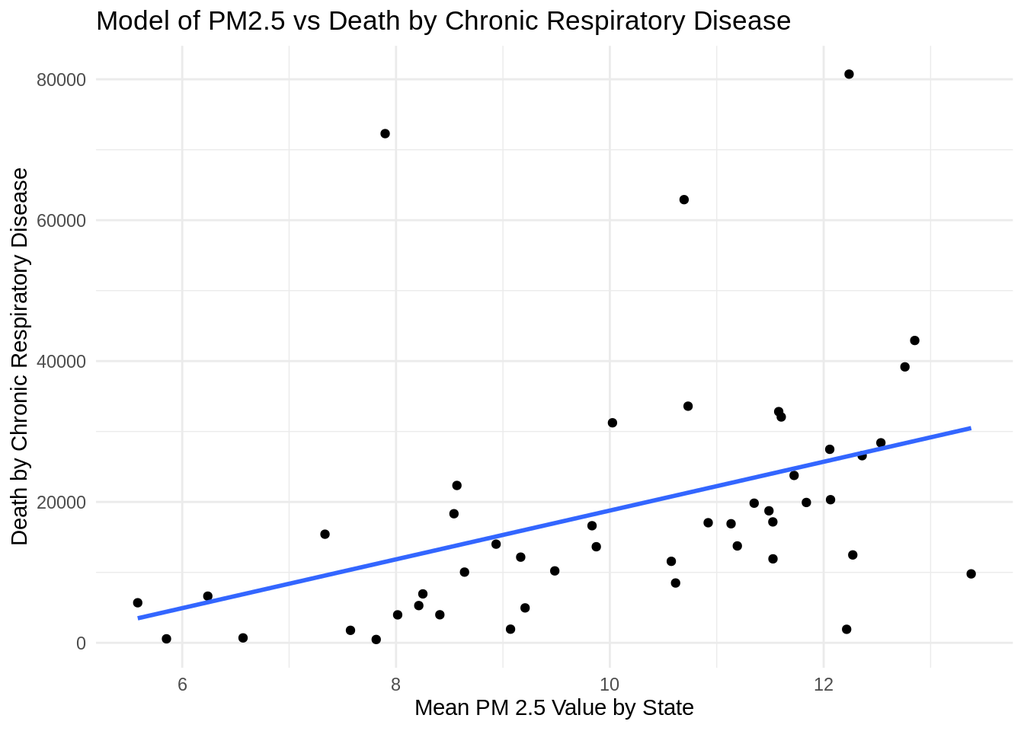

```r
ggplot(ext, aes(x = mean_value, y = CLow)) +
  geom_point() +
  geom_smooth(method = "lm", se = FALSE) +
  labs(title = "Model of PM2.5 vs Death by Chronic Respiratory Disease",
       x = "Mean PM 2.5 Value by State",
       y = "Death by Chronic Respiratory Disease") +
  theme_minimal()
```

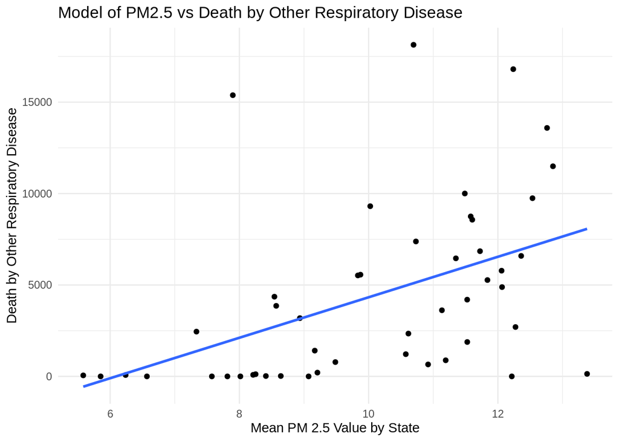

```r
ggplot(ext, aes(x = mean_value, y = Other)) +
  geom_point() +
  geom_smooth(method = "lm", se = FALSE) +
  labs(title = "Model of PM2.5 vs Death by Other Respiratory Disease",
       x = "Mean PM 2.5 Value by State",
       y = "Death by Other Respiratory Disease") +
  theme_minimal()
```

To further explore the relationship between PM 2.5 levels and the number of deaths from respiratory diseases, we conducted linear regression analyses.

**Result:** The results indicate a significant positive relationship; for every unit increase in PM 2.5, there is an estimated increase of 3,463 deaths from chronic lower respiratory diseases and 1,107 deaths from other respiratory diseases. The R-squared values—0.1625 for CLow and 0.2156 for Other—suggest that PM 2.5 levels explain a moderate proportion of the variance in mortality rates. Interestingly, the negative intercepts imply that the model predicts a negative number of deaths at zero PM 2.5 level, highlighting the limitation of using linear models for such data and the potential influence of other unaccounted factors. Nonetheless, the significant coefficients reaffirm the detrimental impact of increased PM 2.5 levels on respiratory health.

Therefore, these results support the hypothesis that higher air pollution levels are associated with increased mortality from all kinds of respiratory diseases at the state level.

## Conclusion

In our study, we explore the data about the average air pollution concentrations across the United States at the granularity of zip code regions. The study shows that there is a correlation between PM2.5 (respirable particulate matter) concentrations in different regions of the United States and factors such as population density, level of urbanization, road density, optical depth, and CMAQ model values. Through a linear regression analysis using the R language, we can see that After our prediction we found a moderate positive correlation between road density and PM2.5 values, implying that areas with higher road density may have more air pollution due to vehicle emissions. Meanwhile, there is a strong positive correlation between the CMAQ model values and PM2.5 values, indicating that the CMAQ model is a powerful predictive tool that can accurately predict PM2.5 pollution levels. In terms of model evaluation, the Random Forest model performed slightly better than the linear regression model with lower MAE and RMSE values, indicating that it has better predictive accuracy and generalization ability when dealing with this type of data. Although the factors had different levels of influence on PM2.5 pollution levels, the CMAQ model and road density were two important predictors.

Our extended analysis focused on the hypothesis of the study was that states with higher concentrations of air pollutants would report higher mortality rates from respiratory diseases. To test this hypothesis, we implemented t-test and linear regression model to compare average mortality rates between states with pollution levels. These statistical methods will shed light on differences in mortality rates and allow us to assess the public health impacts of air pollution across the United States. The results of the study show that there are statistically significant differences, with higher mortality rates due to chronic lower respiratory disease and other respiratory illnesses in states with higher concentrations of pm 2.5.

### References

1. Frontiers | Environmental and Health Impacts of Air Pollution: A Review. https://www.frontiersin.org/articles/10.3389/fpubh.2020.00014/full.Final Report
2. Yanosky, J. D. et al. Spatio-temporal modeling of particulate air pollution in the conterminous United States using geographic and meteorological predictors. Environ. Health 13, 63 (2014).
3. Ellis, P. S. COGS 137 - 15-cs02-data. https://cogs137.github.io/website/content/lectures/15-cs02-data.html#pm-2.5-data (2023).
4. Weekly Counts of Deaths by State and Select Causes, 2014-2019 | Data | Centers for Disease Control and Prevention. https://data.cdc.gov/NCHS/Weekly-Counts-of-Deaths-by-State-and-Select-Causes/3yf8-kanr/about_data.